# Is manual transmission sufficient enough to explain increase of the MPG KPI

schelm56

Thursday, September 15, 2016

##### 0.0.0.0.1 Impact of multiple car parameters onto the mpg KPI

Motor Trend is a autombile trend magazine. It is interested in understanding in exploring the relationship between a set of variables and miles per gallon (MPG) (outcome). In this report we will use a dataset from the 1974 Motor Trend US magazine to answer the following questions:

1. Is an automatic or manual transmission better for MPG?
2. Quantify the MPG difference between automatic and manual transmissions?

###### 0.0.0.0.2.1 Note on the deliverables.

All Deliverables of the Assignment are met except the segragation of Main Part and Appendix. This attempt has been deliberately given up, as the readability would have suffered too much. In order to increase the readability in addition to the required pure RMD file a HTML version is provided.

# 1 Setting the scene : Environment & Data Exploration

## 1.1 Prepare the environment.

### 1.1.1 clear workspace

```r
rm(list=ls())
```

### 1.1.2 Set the Working directory

### 1.1.3 Load relevant Packages

### 1.1.4 Prepare the input

```r
input_data<-mtcars
```

### 1.1.5 Define the table

```r
tbl_input_data <- tbl_df(input_data)
```

## 1.2 Exploratory Data Analysis

### 1.2.1 Formal Exploration of the dataset

```r
?mtcars
```

```
## starting httpd help server ...
```

```
##  done
```

```r
dim(input_data)
```

```
## [1] 32 11
```

```r
summary(input_data)
```

```
##       mpg             cyl             disp             hp
##  Min.   :10.40   Min.   :4.000   Min.   : 71.1   Min.   : 52.0
##  1st Qu.:15.43   1st Qu.:4.000   1st Qu.:120.8   1st Qu.: 96.5
##  Median :19.20   Median :6.000   Median :196.3   Median :123.0
##  Mean   :20.09   Mean   :6.188   Mean   :230.7   Mean   :146.7
##  3rd Qu.:22.80   3rd Qu.:8.000   3rd Qu.:326.0   3rd Qu.:180.0
##  Max.   :33.90   Max.   :8.000   Max.   :472.0   Max.   :335.0
##       drat             wt             qsec             vs
##  Min.   :2.760   Min.   :1.513   Min.   :14.50   Min.   :0.0000
##  1st Qu.:3.080   1st Qu.:2.581   1st Qu.:16.89   1st Qu.:0.0000
##  Median :3.695   Median :3.325   Median :17.71   Median :0.0000
##  Mean   :3.597   Mean   :3.217   Mean   :17.85   Mean   :0.4375
##  3rd Qu.:3.920   3rd Qu.:3.610   3rd Qu.:18.90   3rd Qu.:1.0000
##  Max.   :4.930   Max.   :5.424   Max.   :22.90   Max.   :1.0000
##        am              gear            carb
##  Min.   :0.0000   Min.   :3.000   Min.   :1.000
##  1st Qu.:0.0000   1st Qu.:3.000   1st Qu.:2.000
##  Median :0.0000   Median :4.000   Median :2.000
##  Mean   :0.4062   Mean   :3.688   Mean   :2.812
##  3rd Qu.:1.0000   3rd Qu.:4.000   3rd Qu.:4.000
##  Max.   :1.0000   Max.   :5.000   Max.   :8.000
```

```r
head(input_data)
```

```
##                    mpg cyl disp  hp drat    wt  qsec vs am gear carb
## Mazda RX4         21.0   6  160 110 3.90 2.620 16.46  0  1    4    4
## Mazda RX4 Wag     21.0   6  160 110 3.90 2.875 17.02  0  1    4    4
## Datsun 710        22.8   4  108  93 3.85 2.320 18.61  1  1    4    1
## Hornet 4 Drive    21.4   6  258 110 3.08 3.215 19.44  1  0    3    1
## Hornet Sportabout 18.7   8  360 175 3.15 3.440 17.02  0  0    3    2
## Valiant           18.1   6  225 105 2.76 3.460 20.22  1  0    3    1
```

```r
glimpse(tbl_input_data)
```

```
## Observations: 32
## Variables: 11
## $ mpg  <dbl> 21.0, 21.0, 22.8, 21.4, 18.7, 18.1, 14.3, 24.4, 22.8, 19....
## $ cyl  <dbl> 6, 6, 4, 6, 8, 6, 8, 4, 4, 6, 6, 8, 8, 8, 8, 8, 8, 4, 4, ...
## $ disp <dbl> 160.0, 160.0, 108.0, 258.0, 360.0, 225.0, 360.0, 146.7, 1...
## $ hp   <dbl> 110, 110, 93, 110, 175, 105, 245, 62, 95, 123, 123, 180, ...
## $ drat <dbl> 3.90, 3.90, 3.85, 3.08, 3.15, 2.76, 3.21, 3.69, 3.92, 3.9...
## $ wt   <dbl> 2.620, 2.875, 2.320, 3.215, 3.440, 3.460, 3.570, 3.190, 3...
## $ qsec <dbl> 16.46, 17.02, 18.61, 19.44, 17.02, 20.22, 15.84, 20.00, 2...
## $ vs   <dbl> 0, 0, 1, 1, 0, 1, 0, 1, 1, 1, 1, 0, 0, 0, 0, 0, 0, 1, 1, ...
## $ am   <dbl> 1, 1, 1, 0, 0, 0, 0, 0, 0, 0, 0, 0, 0, 0, 0, 0, 0, 1, 1, ...
## $ gear <dbl> 4, 4, 4, 3, 3, 3, 3, 4, 4, 4, 4, 3, 3, 3, 3, 3, 3, 4, 4, ...
## $ carb <dbl> 4, 4, 1, 1, 2, 1, 4, 2, 2, 4, 4, 3, 3, 3, 4, 4, 4, 1, 2, ...
```

1. Our dataset mtcars contains 32 observations of the following 11 variables. .[, 1] mpg Miles/(US) gallon .[, 2] cyl Number of cylinders .[, 3] disp Displacement (cu.in.) .[, 4] hp Gross horsepower .[, 5] drat Rear axle ratio .[, 6] wt Weight (lb/1000) .[, 7] qsec ¼ mile time .[, 8] vs V/S .[, 9] am Transmission (0 = automatic, 1 = manual) .[,10] gear Number of forward gears .[,11] carb Number of carburetors
2. Conclusion: No Data Cleansing is required in order to properly analyse the data
3. Some Datatransformation is required in order to properly analyse the data
4. Bottomline: am has to be interpreted as a binary factor variable. the reference level is the automatic transmission.

### 1.2.2 Build the factor variables

```r
tbl_input_data$am<-factor(tbl_input_data$am)
levels(tbl_input_data$am)<-c("automatic", "manual")
tbl_input_data$gear<-factor(tbl_input_data$gear)
tbl_input_data$carb<-factor(tbl_input_data$carb)
```

## 1.3 Statistical Exploratory Data Analysis

In order to check the prerequisites on running a linear regression :plot the dependent variable mpg to check its distribution.

```r
par(mfrow = c(1, 2))
```

##### 1.3.0.0.1 Histogram with Normal Curve

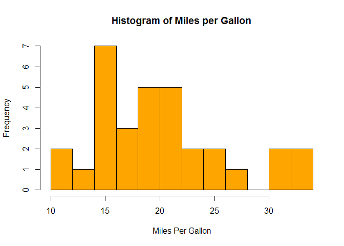

```r
x <- input_data$mpg
h<-hist(x, breaks=10, col="orange", xlab="Miles Per Gallon",
   main="Histogram of Miles per Gallon")
```

#### 1.3.0.1 Kernel Density Plot

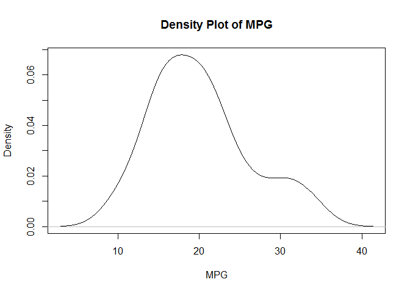

```r
d <- density(input_data$mpg)
plot(d, xlab = "MPG", main ="Density Plot of MPG")
```

Bottomline: - the distribution of mpg is approximately normal  
- no apparent outliers - Prerequisites met

# 2 Main Report

## 2.1 Fit multiple models and detail their strategy for model selection

The first step in the investigation is to take a the initial model which is to be built answering the basic question: mpg varies by automatic versus manual transmission?

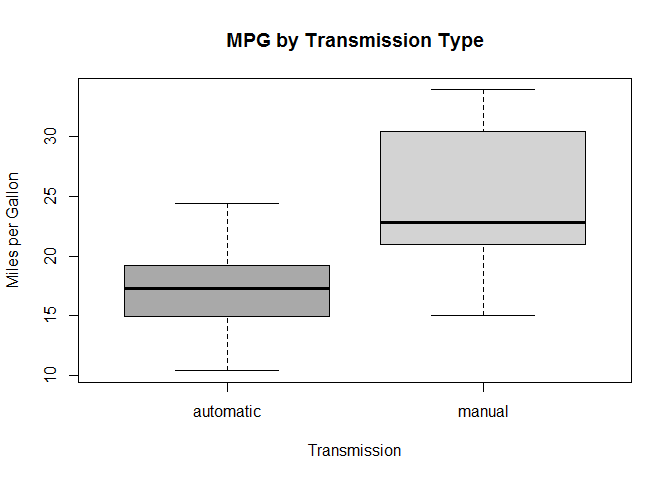

```r
boxplot(mpg~am, data = tbl_input_data,
        col = c("dark grey", "light grey"),
        xlab = "Transmission",
        ylab = "Miles per Gallon",
        main = "MPG by Transmission Type")
```

### 2.1.1 initial model and its significance

Yes, it is obvious: there is a difference in MPG . NOw, its quantity and significance has to be evaluated

```r
model0 <- lm(mpg ~ am , data = tbl_input_data)
mod0<-summary(model0)$coefficients
mod0
```

```
##              Estimate Std. Error   t value     Pr(>|t|)
## (Intercept) 17.147368   1.124603 15.247492 1.133983e-15
## ammanual     7.244939   1.764422  4.106127 2.850207e-04
```

### 2.1.2 Interpretation of the relevant coefficients

Let’s go through each coefficient: Our model estimates an expected 7.25 increase in mpg for the increase of am without considering the remaining variables at all (excluded from the model). Note that t-test for H0 :  
am = 0 versus Ha :  
am ??= 0 significant since the p value of 2.850207e-04 is less than typical benchmarks (0.05, for example) The uncertainty (std. error) of this prediction is identified with 1.76 mpg The intercept is the fitted mpg value when am equal to 0 . In this context it is meaning automatic transmission .

Next step is to analyse if this switch from automatic to manual completely explains the variation in mpg or if we have to include other variables into the explanation.

## 2.2 Prepare the model building strategy

### 2.2.1 Do not include unnessary predictors in the model

For the model building strategy firstly the unnessary variables have to be excluded.

Thus, this systematic approach is performed : 1) all variables are assessed if having impact on MPG with the objective: exclude the unnecessary predictors from the model 2) cluster the parameters and provide the respective correlations :

[figure not shown]

```r
 my_plot_control <- function(data, mapping, ...){
 p <- ggplot(data = data, mapping = mapping)
 geom_point()
 geom_smooth(method=loess, fill="red", color="red", ...)
 geom_smooth(method=lm, fill="blue", color="blue", ...)

 p
  }
  g = ggpairs(mtcars,columns = 1:11, lower = list(continuous = my_plot_control))
 g
```

List of the correlations:

```r
sort(cor(input_data)[1,])
```

```
##         wt        cyl       disp         hp       carb       qsec
## -0.8676594 -0.8521620 -0.8475514 -0.7761684 -0.5509251  0.4186840
##       gear         am         vs       drat        mpg
##  0.4802848  0.5998324  0.6640389  0.6811719  1.0000000
```

Based on these correlations 2 cluster are built:

```r
model1 <- lm(mpg ~ . , data = input_data)

summary(model1)$coefficients
```

```
##                Estimate  Std. Error    t value   Pr(>|t|)
## (Intercept) 12.30337416 18.71788443  0.6573058 0.51812440
## cyl         -0.11144048  1.04502336 -0.1066392 0.91608738
## disp         0.01333524  0.01785750  0.7467585 0.46348865
## hp          -0.02148212  0.02176858 -0.9868407 0.33495531
## drat         0.78711097  1.63537307  0.4813036 0.63527790
## wt          -3.71530393  1.89441430 -1.9611887 0.06325215
## qsec         0.82104075  0.73084480  1.1234133 0.27394127
## vs           0.31776281  2.10450861  0.1509915 0.88142347
## am           2.52022689  2.05665055  1.2254035 0.23398971
## gear         0.65541302  1.49325996  0.4389142 0.66520643
## carb        -0.19941925  0.82875250 -0.2406258 0.81217871
```

#### 2.2.1.1 Cluster 1 - Negatitve correlation

The mpg decreases with these respective variables increasing while holding the other variables constant:

wt -3.71530393 1.89441430 -1.9611887 0.06325215 carb -0.19941925 0.82875250 -0.2406258 0.81217871 cyl -0.11144048 1.04502336 -0.1066392 0.91608738 hp -0.02148212 0.02176858 -0.9868407 0.33495531

This means: e.g. If wt increases by 1 unit (lb/1000) we expect the mpg will decrease by 3.7

### 2.2.2 Visual Validation: negative correlation

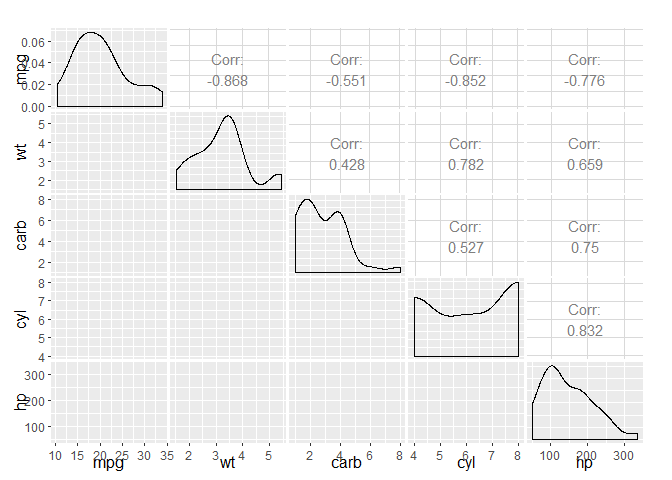

```r
neg_corr <-input_data %>% select(mpg, wt,  carb  ,  cyl   ,hp)
g = ggpairs(neg_corr,columns = 1:5, lower = list(continuous = my_plot_control))
g
```

Conclusion: 1)As expected: The variables wt, carb , cyl ,hp have a decreasing effect on mpg. 2) Interstingly: amongst each other wt, carb , cyl ,hp have an increasing effect. e.g. increasing wt results positively in increasing carb,cyl ,hp. **Action:** 1) It has to be investigated if there are interdepencies between wt,carb,cyl ,hp . 2)It has to be investigated if there are confounding effects between these and the automatic transmission

The mpg increases with these respective variables increasing - while holding the other variables constant:

am 2.52022689 2.05665055 1.2254035 0.23398971 qsec 0.82104075 0.73084480 1.1234133 0.27394127 drat 0.78711097 1.63537307 0.4813036 0.63527790 gear 0.65541302 1.49325996 0.4389142 0.66520643 vs 0.31776281 2.10450861 0.1509915 0.88142347 disp 0.01333524 0.01785750 0.7467585 0.46348865

This means: e.g. If Rear axle ratio increases by 1 unit we expect the mpg will increase by 0.79 Special Focus is to be kept on the aspect which might be relevant for the report question:

None of these - by itself - are significant. Therefore we need a combination to explain the positiive impact.

### 2.2.3 Visual Validation: positive correlation

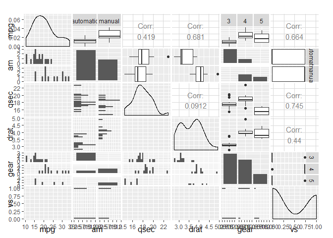

```r
 pos_corr <-tbl_input_data %>% select(mpg,am , qsec,drat , gear  , vs,  disp)
  g = ggpairs(pos_corr,columns = 1:6, lower = list(continuous = my_plot_control))
  g
```

**Result:**

No surprise: increasing am results positively in increasing gear!!!

**Action:** It has to be investigated if there are interdepencies.Thus: As mpg increases with the switch to manual transmission it has to be investigated if the variables drat, gear, vs - which are positively correlated to manual transmission - better explain the increase in mileage.

## 2.3 fit multiple models and detail their strategy for model selection

As the stepwise regression have downsides( http://davegiles.blogspot.com/2014/07/step-wise-regression.html) it is used for validation.

### 2.3.1 Cluster 2 - explanatory variables impacting increasing mpg

#### 2.3.1.1 Confounding explanatory variables impacting increasing mpg

Thus, this systematic step by step approach is performed :

```r
#mpg,am , qsec,drat , gear  , vs,  disp
cor_drat_vs <- cor( input_data$vs,input_data$drat)
cor_gear_drat <- cor( input_data$drat,input_data$gear)
cor_drat_disp <- cor( input_data$disp,input_data$drat)
cor_disp_gear <- cor( input_data$disp,input_data$gear)
cor_vs_gear <- cor( input_data$vs,input_data$gear)
cor_vs_disp <- cor( input_data$vs,input_data$disp)
cor_qsec_drat <- cor( input_data$qsec,input_data$drat)
cor_qsec_gear <- cor( input_data$qsec,input_data$gear)
cor_qsec_disp <- cor( input_data$qsec,input_data$disp)
cor_vs_qsec <- cor( input_data$vs,input_data$qsec)
```

Next step is to use this short list for building the positive cluster models.

```r
fit<-lm(mpg~gear+am+ qsec+drat + gear + vs+  disp,data=input_data)
fit5<-lm(mpg~qsec+drat + gear + vs+  disp,data=input_data)
fit6<-lm(mpg~qsec+drat +  vs,data=input_data)
fit1<-lm(mpg~gear+vs,data=input_data)
fit2<-lm(mpg~gear+vs+drat,data=input_data)
fit3<-lm(mpg~gear+drat,data=input_data)
fit4<-lm(mpg~drat+vs,data=input_data)
summary(fit)$coefficients
```

```
##                Estimate   Std. Error    t value   Pr(>|t|)
## (Intercept) 11.94826450 15.006726789  0.7961939 0.43341525
## gear        -1.20888256  1.391091759 -0.8690171 0.39310450
## am           4.63467773  2.248419885  2.0613044 0.04981844
## qsec         0.58534448  0.613166897  0.9546250 0.34890758
## drat         1.31297257  1.832918789  0.7163288 0.48042691
## vs           1.50455182  2.241443500  0.6712424 0.50822135
## disp        -0.02215143  0.009647264 -2.2961360 0.03032622
```

```r
summary(fit1)$coefficients
```

```
##             Estimate Std. Error  t value     Pr(>|t|)
## (Intercept) 6.198330   3.765707 1.645994 1.105617e-01
## gear        2.930157   1.023393 2.863180 7.713335e-03
## vs          7.056778   1.498093 4.710506 5.668409e-05
```

```r
summary(fit2)$coefficients
```

```
##               Estimate Std. Error    t value    Pr(>|t|)
## (Intercept) -1.8416402   4.956029 -0.3715960 0.712990962
## gear         0.8175089   1.324900  0.6170344 0.542197477
## vs           5.5526780   1.543433  3.5976150 0.001221879
## drat         4.5844899   1.992525  2.3008445 0.029057748
```

```r
summary(fit3)$coefficients
```

```
##                Estimate Std. Error     t value    Pr(>|t|)
## (Intercept) -7.53747372   5.580198 -1.35075389 0.187220607
## gear         0.05968008   1.554223  0.03839865 0.969632961
## drat         7.62061786   2.144675  3.55327346 0.001324853
```

```r
summary(fit4)$coefficients
```

```
##              Estimate Std. Error    t value     Pr(>|t|)
## (Intercept) -1.825317   4.902758 -0.3723041 0.7123734181
## drat         5.436549   1.420995  3.8258760 0.0006405377
## vs           5.401262   1.507443  3.5830623 0.0012245503
```

```r
summary(fit5)$coefficients
```

```
##                Estimate   Std. Error     t value    Pr(>|t|)
## (Intercept) 14.80955521 15.848521020  0.93444399 0.358672981
## qsec         0.20682343  0.620500722  0.33331699 0.741568121
## drat         2.32081571  1.873626971  1.23867544 0.226532712
## gear        -0.09417907  1.359400732 -0.06927985 0.945296960
## vs           1.11584287  2.368939800  0.47103049 0.641547165
## disp        -0.02989888  0.009423803 -3.17269756 0.003854666
```

```r
summary(fit6)$coefficients
```

```
##               Estimate Std. Error    t value     Pr(>|t|)
## (Intercept) -8.7166508 13.5556589 -0.6430267 0.5254381932
## qsec         0.3442016  0.6300515  0.5463071 0.5891819216
## drat         5.7741658  1.5656326  3.6880719 0.0009633664
## vs           4.3349911  2.4775320  1.7497215 0.0911203441
```

```r
anova(fit,fit1, fit2, fit3, fit4,fit5,fit6)
```

```
## Analysis of Variance Table
##
## Model 1: mpg ~ gear + am + qsec + drat + gear + vs + disp
## Model 2: mpg ~ gear + vs
## Model 3: mpg ~ gear + vs + drat
## Model 4: mpg ~ gear + drat
## Model 5: mpg ~ drat + vs
## Model 6: mpg ~ qsec + drat + gear + vs + disp
## Model 7: mpg ~ qsec + drat + vs
##   Res.Df    RSS Df Sum of Sq       F    Pr(>F)
## 1     25 246.91
## 2     29 490.78 -4  -243.872  6.1730 0.0013448 **
## 3     28 412.75  1    78.037  7.9013 0.0094639 **
## 4     29 603.54 -1  -190.790 19.3176 0.0001787 ***
## 5     29 418.36  0   185.177
## 6     26 288.88  3   129.482  4.3701 0.0132175 *
## 7     28 413.95 -2  -125.070  6.3317 0.0059601 **
## ---
## Signif. codes:  0 '***' 0.001 '**' 0.01 '*' 0.05 '.' 0.1 ' ' 1
```

Because of confounding impact qsec can be excluded.

Result: the shortlist of the increasing mpg parameters now consist of drat, vs, gear.

#### 2.3.1.2 Interaction of explanatory variables impacting increasing mpg

Now, the interaction of drat, vs, gear with am has to be assessed

#### 2.3.1.3 diagnostic plots on the interaction of drat, vs, gear with am

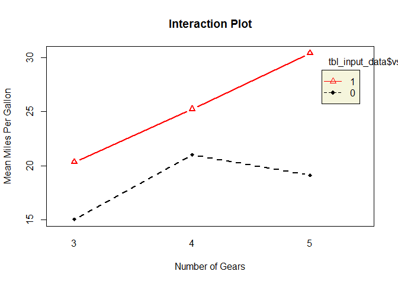

```r
interaction.plot( tbl_input_data$gear, tbl_input_data$vs,tbl_input_data$mpg, type="b", col=c(1:3),
                  leg.bty="o", leg.bg="beige", lwd=2, pch=c(18,24,22),
                       xlab="Number of Gears",
                       ylab="Mean Miles Per Gallon",
                       main="Interaction Plot")
```

There is no obvious interaction between Gears and vs, having vs with the stronger increase impact on mpg

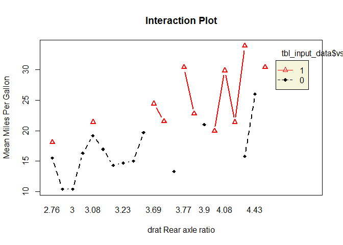

```
                   There is no obvious interaction between Drat and vs.
```

```r
interaction.plot( tbl_input_data$drat, tbl_input_data$vs,tbl_input_data$mpg, type="b", col=c(1:3),
                   leg.bty="o", leg.bg="beige", lwd=2, pch=c(18,24,22),
                       xlab="drat Rear axle ratio",
                       ylab="Mean Miles Per Gallon", main="Interaction Plot")
```

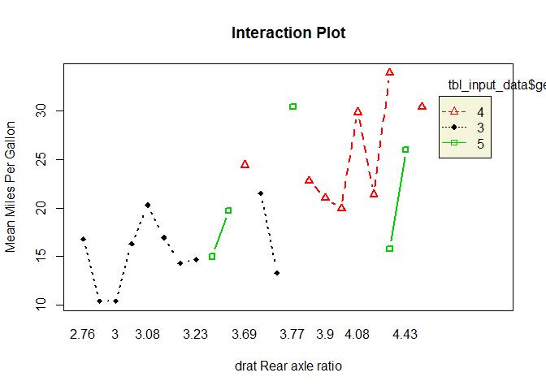

```
                   There is some interaction between Drat and gear around 4 drat and 4 gears
```

```r
interaction.plot( tbl_input_data$drat, tbl_input_data$gear,tbl_input_data$mpg, type="b", col=c(1:3),
                   leg.bty="o", leg.bg="beige", lwd=2, pch=c(18,24,22),
                       xlab="drat Rear axle ratio",
                       ylab="Mean Miles Per Gallon", main="Interaction Plot")
```

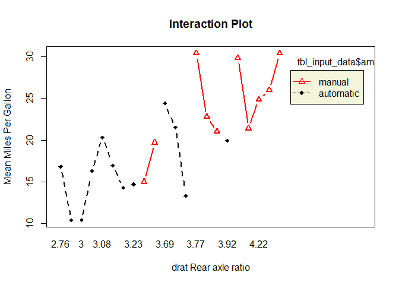

```r
interaction.plot( tbl_input_data$drat, tbl_input_data$am,tbl_input_data$mpg, type="b", col=c(1:3),
                   leg.bty="o", leg.bg="beige", lwd=2, pch=c(18,24,22),
                       xlab="drat Rear axle ratio",
                       ylab="Mean Miles Per Gallon",
                      main="Interaction Plot")
```

There is interaction between Drat and am, having drat around 4 and manual transmission with the best increasing impact on mpg

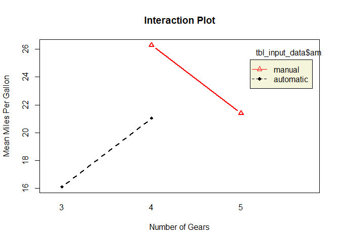

```r
 interaction.plot( tbl_input_data$gear, tbl_input_data$am,tbl_input_data$mpg, type="b", col=c(1:3),
                   leg.bty="o", leg.bg="beige", lwd=2, pch=c(18,24,22),
                       xlab="Number of Gears",
                       ylab="Mean Miles Per Gallon",
                      main="Interaction Plot")
```

There is interaction between Gear and am with optimum on 4 Gears, having am with the stronger increase impact on mpg

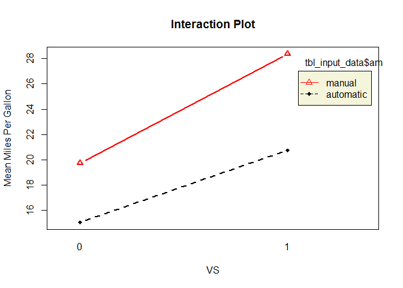

```r
interaction.plot( tbl_input_data$vs, tbl_input_data$am,tbl_input_data$mpg, type="b", col=c(1:3),
                   leg.bty="o", leg.bg="beige", lwd=2, pch=c(18,24,22),
                       xlab="VS",
                       ylab="Mean Miles Per Gallon",
                      main="Interaction Plot")
```

There is an interaction between vs and am, having both increasing impact on mpg with am

Result after the interaction analysis: the shortlist now consists only of am. Because of interaction vs and drat.

```r
a<-summary(fm1 <- aov(mpg ~ am + vs+drat+gear, data = input_data))
```

### 2.3.2 Cluster 1 - explanatory variables impacting decreasing mpg

Now the variables with decreasing effect have to evaluated if to be included in the model. These variables are expected to have a smoothing effect on the increasing impact of manual transmission onto mpg.

### 2.3.3 Confounding variables impacting decreasing mpg

```r
#mpg,am ,  wt,  carb  ,  cyl   ,hp
cor_carb_wt <- cor( input_data$wt,input_data$carb)
cor_cyl_carb <- cor( input_data$carb,input_data$cyl)
cor_carb_hp <- cor( input_data$hp,input_data$carb)
cor_hp_cyl <- cor( input_data$hp,input_data$cyl)
cor_wt_cyl <- cor( input_data$wt,input_data$cyl)
cor_wt_hp <- cor( input_data$wt,input_data$hp)
```

Result: So far the correlation analysis did not identify any uneccessary variable.

Next step is to use this result for building the negative cluster models.

```r
# wt,  carb  ,  cyl   ,hp
fit<-lm(mpg~hp+ cyl+carb +  wt,data=input_data)


summary(fit)$coefficients
```

```
##                Estimate Std. Error    t value     Pr(>|t|)
## (Intercept) 39.04586846 1.86690312 20.9147802 3.268406e-18
## hp          -0.01143663 0.01599223 -0.7151367 4.806632e-01
## cyl         -1.02465565 0.57263823 -1.7893595 8.478144e-02
## carb        -0.27666923 0.44268073 -0.6249859 5.372269e-01
## wt          -3.15780346 0.74891254 -4.2165183 2.490304e-04
```

```r
anova(fit)
```

```
## Analysis of Variance Table
##
## Response: mpg
##           Df Sum Sq Mean Sq  F value    Pr(>F)
## hp         1 678.37  678.37 105.2032 8.217e-11 ***
## cyl        1 155.70  155.70  24.1462 3.839e-05 ***
## carb       1   3.23    3.23   0.5009  0.485180
## wt         1 114.64  114.64  17.7790  0.000249 ***
## Residuals 27 174.10    6.45
## ---
## Signif. codes:  0 '***' 0.001 '**' 0.01 '*' 0.05 '.' 0.1 ' ' 1
```

Basically, the explanatory variable carb is identified to be excluded as confounding . The remaining wt,cyl, hp are having a high F value and low p value.Thus these are to be included in the final model analysis.

```r
a<-summary(fm1 <- aov(mpg ~ am + cyl+hp+wt, data = input_data))
 a
```

```
##             Df Sum Sq Mean Sq F value   Pr(>F)
## am           1  405.2   405.2  64.348 1.28e-08 ***
## cyl          1  449.5   449.5  71.398 4.62e-09 ***
## hp           1   50.8    50.8   8.070  0.00846 **
## wt           1   50.6    50.6   8.029  0.00860 **
## Residuals   27  170.0     6.3
## ---
## Signif. codes:  0 '***' 0.001 '**' 0.01 '*' 0.05 '.' 0.1 ' ' 1
```

Result after the interaction analysis: the shortlist of the decreasing mpg parameters now consist of am hp, wt, cyl. WHy? am and cyl show the variation of mpg means among different am resp. cyl (numerator) is much larger than the variation of mpg within cyl/am type, and our p-value is less than 0.05 (as suggested by normal scientific standard). As well for wt and hp our p-value is less than 0.05.Hence we can conclude that for our confidence interval we accept the alternative hypothesis H1 that there is a significant relationship between am, cyl, hp, wt and mpg.

### 2.3.4 Build the final model

Approach: Based on the previous analysis steps the final shortlist is to be compiled with am, cyl,vs,hp, wt to investigate the impact on mpg. It is compared with the control model

```r
#am, cyl,vs, hp,wt

model_prelim<-lm(mpg~am+vs+cyl+hp+wt,data= tbl_input_data)
model_con<-lm(mpg~am,data= tbl_input_data)
summary(model_prelim)$coef
```

```
##                Estimate Std. Error    t value     Pr(>|t|)
## (Intercept) 33.24159905 5.48527074  6.0601565 2.108602e-06
## ammanual     1.97574750 1.64825342  1.1986916 2.414597e-01
## vs           1.17066640 1.81282822  0.6457680 5.240886e-01
## cyl         -0.40178727 0.79364098 -0.5062582 6.169415e-01
## hp          -0.02588661 0.01387176 -1.8661377 7.334148e-02
## wt          -2.54331718 0.93506164 -2.7199460 1.148231e-02
```

```r
#layout(matrix(c(1,2,3,4),2,2)) # optional layout
#plot(model_prelim) # diagnostic plots
summary(model_con)$coef
```

```
##              Estimate Std. Error   t value     Pr(>|t|)
## (Intercept) 17.147368   1.124603 15.247492 1.133983e-15
## ammanual     7.244939   1.764422  4.106127 2.850207e-04
```

```r
anova (model_prelim,model_con)
```

```
## Analysis of Variance Table
##
## Model 1: mpg ~ am + vs + cyl + hp + wt
## Model 2: mpg ~ am
##   Res.Df    RSS Df Sum of Sq      F    Pr(>F)
## 1     26 167.31
## 2     30 720.90 -4   -553.58 21.506 6.227e-08 ***
## ---
## Signif. codes:  0 '***' 0.001 '**' 0.01 '*' 0.05 '.' 0.1 ' ' 1
```

```r
#am, cyl, hp,wt
 model_int<-lm(mpg~am+cyl+hp+wt,data= tbl_input_data)
model_con<-lm(mpg~am,data= tbl_input_data)
summary(model_int)$coef
```

```
##                Estimate Std. Error   t value     Pr(>|t|)
## (Intercept) 36.14653575 3.10478079 11.642218 4.944804e-12
## ammanual     1.47804771 1.44114927  1.025603 3.141799e-01
## cyl         -0.74515702 0.58278741 -1.278609 2.119166e-01
## hp          -0.02495106 0.01364614 -1.828433 7.855337e-02
## wt          -2.60648071 0.91983749 -2.833632 8.603218e-03
```

```r
#layout(matrix(c(1,2,3,4),2,2)) # optional layout
#plot(model_int) # diagnostic plots
#plot(model_con) # diagnostic plots
summary(model_con)$coef
```

```
##              Estimate Std. Error   t value     Pr(>|t|)
## (Intercept) 17.147368   1.124603 15.247492 1.133983e-15
## ammanual     7.244939   1.764422  4.106127 2.850207e-04
```

```r
anova (model_int,model_con)
```

```
## Analysis of Variance Table
##
## Model 1: mpg ~ am + cyl + hp + wt
## Model 2: mpg ~ am
##   Res.Df   RSS Df Sum of Sq      F    Pr(>F)
## 1     27 170.0
## 2     30 720.9 -3    -550.9 29.166 1.274e-08 ***
## ---
## Signif. codes:  0 '***' 0.001 '**' 0.01 '*' 0.05 '.' 0.1 ' ' 1
```

```r
mean(summary (model_int)$residuals)
```

```
## [1] 2.75821e-16
```

```r
model_4 <- step(model_int, direction = "both")
```

```
## Start:  AIC=63.44
## mpg ~ am + cyl + hp + wt
##
##        Df Sum of Sq    RSS    AIC
## - am    1     6.623 176.62 62.665
## - cyl   1    10.293 180.29 63.323
## <none>              170.00 63.442
## - hp    1    21.049 191.05 65.177
## - wt    1    50.555 220.55 69.773
##
## Step:  AIC=62.66
## mpg ~ cyl + hp + wt
##
##        Df Sum of Sq    RSS    AIC
## <none>              176.62 62.665
## - hp    1    14.551 191.17 63.198
## + am    1     6.623 170.00 63.442
## - cyl   1    18.427 195.05 63.840
## - wt    1   115.354 291.98 76.750
```

```r
#am,  hp,wt
model_fin<-lm(mpg~am+hp+wt,data= tbl_input_data)
model_con<-lm(mpg~am,data= tbl_input_data)
summary(model_fin)$coef
```

```
##                Estimate  Std. Error   t value     Pr(>|t|)
## (Intercept) 34.00287512 2.642659337 12.866916 2.824030e-13
## ammanual     2.08371013 1.376420152  1.513862 1.412682e-01
## hp          -0.03747873 0.009605422 -3.901830 5.464023e-04
## wt          -2.87857541 0.904970538 -3.180850 3.574031e-03
```

```r
#layout(matrix(c(1,2,3,4),2,2)) # optional layout
#plot(model_fin) # diagnostic plots
#plot(model_con) # diagnostic plots
summary(model_con)$coef
```

```
##              Estimate Std. Error   t value     Pr(>|t|)
## (Intercept) 17.147368   1.124603 15.247492 1.133983e-15
## ammanual     7.244939   1.764422  4.106127 2.850207e-04
```

```r
mean(summary (model_fin)$residuals)
```

```
## [1] 1.561251e-16
```

```r
anova (model_fin,model_con)
```

```
## Analysis of Variance Table
##
## Model 1: mpg ~ am + hp + wt
## Model 2: mpg ~ am
##   Res.Df    RSS Df Sum of Sq      F    Pr(>F)
## 1     28 180.29
## 2     30 720.90 -2   -540.61 41.979 3.745e-09 ***
## ---
## Signif. codes:  0 '***' 0.001 '**' 0.01 '*' 0.05 '.' 0.1 ' ' 1
```

The model output indicates some evidence of a difference in the average growth of mpg with the control model. Therefore we perform a stepwise regression:

```r
model_2 <- step(model_fin, direction = "forward")
```

```
## Start:  AIC=63.32
## mpg ~ am + hp + wt
```

```r
#Start:  AIC=63.44
#mpg ~ cyl + hp + wt

anova (model_fin,model_con)
```

```
## Analysis of Variance Table
##
## Model 1: mpg ~ am + hp + wt
## Model 2: mpg ~ am
##   Res.Df    RSS Df Sum of Sq      F    Pr(>F)
## 1     28 180.29
## 2     30 720.90 -2   -540.61 41.979 3.745e-09 ***
## ---
## Signif. codes:  0 '***' 0.001 '**' 0.01 '*' 0.05 '.' 0.1 ' ' 1
```

```r
model_org <- step(model0, direction = "forward")
```

```
## Start:  AIC=103.67
## mpg ~ am
```

```r
#Start:  AIC=103.67
#mpg ~ am
model_opt <- step(model1, direction = "forward")
```

```
## Start:  AIC=70.9
## mpg ~ cyl + disp + hp + drat + wt + qsec + vs + am + gear + carb
```

```r
#Start:  AIC=70.9
#mpg ~ wt + qsec + am
```

As the 2 models are very close and depending on the direction of stepwise regression: Next step is to compare the adjusted R-squared of these 2 models

```r
summary(model_opt)
```

```
##
## Call:
## lm(formula = mpg ~ cyl + disp + hp + drat + wt + qsec + vs +
##     am + gear + carb, data = input_data)
##
## Residuals:
##     Min      1Q  Median      3Q     Max
## -3.4506 -1.6044 -0.1196  1.2193  4.6271
##
## Coefficients:
##             Estimate Std. Error t value Pr(>|t|)
## (Intercept) 12.30337   18.71788   0.657   0.5181
## cyl         -0.11144    1.04502  -0.107   0.9161
## disp         0.01334    0.01786   0.747   0.4635
## hp          -0.02148    0.02177  -0.987   0.3350
## drat         0.78711    1.63537   0.481   0.6353
## wt          -3.71530    1.89441  -1.961   0.0633 .
## qsec         0.82104    0.73084   1.123   0.2739
## vs           0.31776    2.10451   0.151   0.8814
## am           2.52023    2.05665   1.225   0.2340
## gear         0.65541    1.49326   0.439   0.6652
## carb        -0.19942    0.82875  -0.241   0.8122
## ---
## Signif. codes:  0 '***' 0.001 '**' 0.01 '*' 0.05 '.' 0.1 ' ' 1
##
## Residual standard error: 2.65 on 21 degrees of freedom
## Multiple R-squared:  0.869,  Adjusted R-squared:  0.8066
## F-statistic: 13.93 on 10 and 21 DF,  p-value: 3.793e-07
```

```r
summary(model_2)
```

```
##
## Call:
## lm(formula = mpg ~ am + hp + wt, data = tbl_input_data)
##
## Residuals:
##     Min      1Q  Median      3Q     Max
## -3.4221 -1.7924 -0.3788  1.2249  5.5317
##
## Coefficients:
##              Estimate Std. Error t value Pr(>|t|)
## (Intercept) 34.002875   2.642659  12.867 2.82e-13 ***
## ammanual     2.083710   1.376420   1.514 0.141268
## hp          -0.037479   0.009605  -3.902 0.000546 ***
## wt          -2.878575   0.904971  -3.181 0.003574 **
## ---
## Signif. codes:  0 '***' 0.001 '**' 0.01 '*' 0.05 '.' 0.1 ' ' 1
##
## Residual standard error: 2.538 on 28 degrees of freedom
## Multiple R-squared:  0.8399, Adjusted R-squared:  0.8227
## F-statistic: 48.96 on 3 and 28 DF,  p-value: 2.908e-11
```

```r
adj.r2<-c(summary(model_opt)$adj.r.squared,
  summary(model_2)$adj.r.squared,
  summary(model0)$adj.r.squared)

names(adj.r2)<-c("model_optimal", "model2", "model0" )
print(adj.r2)
```

```
## model_optimal        model2        model0
##     0.8066423     0.8227357     0.3384589
```

### 2.3.5 Final result of the analysis

Before we report the details of our model, it is important to check the residuals for any signs of non-normality and examine the residuals vs. fitted values plot to spot for any signs of heteroskedasticity

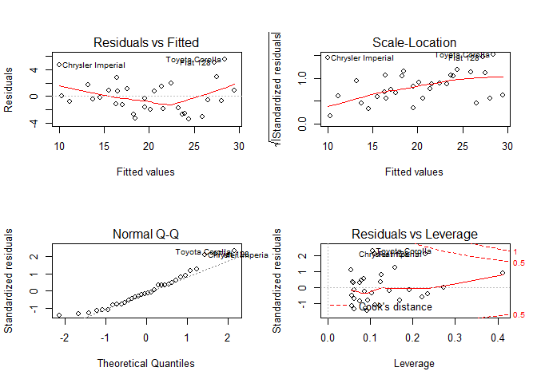

```r
layout(matrix(c(1,2,3,4),2,2)) # optional layout
 plot(model_fin) # diagnostic plots
```

```r
#final model results
summary(model_opt)
```

```
##
## Call:
## lm(formula = mpg ~ cyl + disp + hp + drat + wt + qsec + vs +
##     am + gear + carb, data = input_data)
##
## Residuals:
##     Min      1Q  Median      3Q     Max
## -3.4506 -1.6044 -0.1196  1.2193  4.6271
##
## Coefficients:
##             Estimate Std. Error t value Pr(>|t|)
## (Intercept) 12.30337   18.71788   0.657   0.5181
## cyl         -0.11144    1.04502  -0.107   0.9161
## disp         0.01334    0.01786   0.747   0.4635
## hp          -0.02148    0.02177  -0.987   0.3350
## drat         0.78711    1.63537   0.481   0.6353
## wt          -3.71530    1.89441  -1.961   0.0633 .
## qsec         0.82104    0.73084   1.123   0.2739
## vs           0.31776    2.10451   0.151   0.8814
## am           2.52023    2.05665   1.225   0.2340
## gear         0.65541    1.49326   0.439   0.6652
## carb        -0.19942    0.82875  -0.241   0.8122
## ---
## Signif. codes:  0 '***' 0.001 '**' 0.01 '*' 0.05 '.' 0.1 ' ' 1
##
## Residual standard error: 2.65 on 21 degrees of freedom
## Multiple R-squared:  0.869,  Adjusted R-squared:  0.8066
## F-statistic: 13.93 on 10 and 21 DF,  p-value: 3.793e-07
```

# 3 Apendix